# R Notebook

```r
df_merged_d <- add_predictions(ols1d, df_merged_d, "predicted_sales1")

# Model 2: Backward
head(df_merged_d)
```

|  | date | sales_cop | bar | food | rain_sum | fx | tmedian | numeric_day | seasonal_month | day_of_week | predicted_sales0 | predicted_sales1 |
| --- | --- | --- | --- | --- | --- | --- | --- | --- | --- | --- | --- | --- |
| 1 | 2021-11-30 | 14.21677 | 13.43425 | 13.60565 | 6.355253 | 8.297040 | 3.081910 | 3.433987 | November | Tuesday | 12.84593 | 12.50660 |
| 2 | 2021-12-01 | 13.42054 | 12.51356 | 12.90346 | 6.568903 | 8.295434 | 3.152736 | 3.465736 | December | Wednesday | 12.86744 | 12.01141 |
| 3 | 2021-12-02 | 14.00224 | 13.24635 | 13.36813 | 6.260732 | 8.282549 | 3.234749 | 3.496508 | December | Thursday | 12.88828 | 12.27882 |
| 4 | 2021-12-03 | 14.10885 | 13.18722 | 13.60158 | 6.302952 | 8.280503 | 3.182212 | 3.526361 | December | Friday | 12.90850 | 12.93076 |
| 5 | 2021-12-04 | 14.11094 | 12.91657 | 13.75012 | 6.399608 | 8.281301 | 3.186353 | 3.555348 | December | Saturday | 12.92814 | 12.77673 |
| 6 | 2021-12-05 | 12.79636 | 10.93312 | 12.62774 | 6.254944 | 8.281301 | 3.234749 | 3.583519 | December | Sunday | 12.94722 | 12.47178 |

```r
# Start with the full model (excluding food and bar)
ols2_full_d <- lm(
  sales_cop ~ numeric_day + seasonal_month + day_of_week + fx +
     tmedian + rain_sum,
  data = df_merged_d
)
summary(ols2_full_d)
```

```
Call:
lm(formula = sales_cop ~ numeric_day + seasonal_month + day_of_week +
    fx + tmedian + rain_sum, data = df_merged_d)

Residuals:
     Min       1Q   Median       3Q      Max
-15.2560  -0.1301   0.1434   0.4180   2.2430

Coefficients:
                         Estimate Std. Error t value
(Intercept)              3.681458   7.563025   0.487
numeric_day              0.555771   0.078969   7.038
seasonal_monthFebruary   0.409437   0.263765   1.552
seasonal_monthMarch      0.254867   0.257099   0.991
seasonal_monthApril      0.215634   0.264563   0.815
seasonal_monthMay        0.002179   0.263006   0.008
seasonal_monthJune       0.125315   0.268566   0.467
seasonal_monthJuly       0.230188   0.260048   0.885
seasonal_monthAugust     0.284052   0.260701   1.090
seasonal_monthSeptember  0.004766   0.265632   0.018
seasonal_monthOctober    0.152011   0.266104   0.571
seasonal_monthNovember  -0.092994   0.303301  -0.307
seasonal_monthDecember  -0.744359   0.258962  -2.874
day_of_weekTuesday      -0.063129   0.198020  -0.319
day_of_weekWednesday     0.237591   0.197534   1.203
day_of_weekThursday      0.471793   0.197065   2.394
day_of_weekFriday        1.102140   0.198329   5.557
day_of_weekSaturday      0.930391   0.198011   4.699
day_of_weekSunday        0.615126   0.198134   3.105
fx                       0.787878   0.880843   0.894
tmedian                 -0.143825   0.999347  -0.144
rain_sum                 0.137507   0.101046   1.361
                        Pr(>|t|)
(Intercept)              0.62653
numeric_day             3.58e-12 ***
seasonal_monthFebruary   0.12091
seasonal_monthMarch      0.32176
seasonal_monthApril      0.41523
seasonal_monthMay        0.99339
seasonal_monthJune       0.64088
seasonal_monthJuly       0.37627
seasonal_monthAugust     0.27616
seasonal_monthSeptember  0.98569
seasonal_monthOctober    0.56796
seasonal_monthNovember   0.75921
seasonal_monthDecember   0.00413 **
day_of_weekTuesday       0.74994
day_of_weekWednesday     0.22934
day_of_weekThursday      0.01684 *
day_of_weekFriday       3.50e-08 ***
day_of_weekSaturday     2.98e-06 ***
day_of_weekSunday        0.00196 **
fx                       0.37129
tmedian                  0.88559
rain_sum                 0.17387
---
Signif. codes:
0 ‘***’ 0.001 ‘**’ 0.01 ‘*’ 0.05 ‘.’ 0.1 ‘ ’ 1

Residual standard error: 1.703 on 1018 degrees of freedom
Multiple R-squared:  0.1609,    Adjusted R-squared:  0.1436
F-statistic: 9.294 on 21 and 1018 DF,  p-value: < 2.2e-16
```

```r
# Perform backward stepwise regression
ols2_stepwise_d <- step(
  ols2_full_d,
  direction = "backward",
  trace = 1 # Prints the stepwise regression process
)
```

```
Start:  AIC=1128.63
sales_cop ~ numeric_day + seasonal_month + day_of_week + fx +
    tmedian + rain_sum

                 Df Sum of Sq    RSS    AIC
- tmedian         1     0.060 2951.0 1126.7
- fx              1     2.319 2953.3 1127.5
- rain_sum        1     5.368 2956.3 1128.5
<none>                        2951.0 1128.6
- seasonal_month 11    79.118 3030.1 1134.2
- numeric_day     1   143.580 3094.6 1176.0
- day_of_week     6   175.600 3126.6 1176.8

Step:  AIC=1126.65
sales_cop ~ numeric_day + seasonal_month + day_of_week + fx +
    rain_sum

                 Df Sum of Sq    RSS    AIC
- fx              1     2.277 2953.3 1125.5
<none>                        2951.0 1126.7
- rain_sum        1     6.045 2957.1 1126.8
- seasonal_month 11    79.429 3030.5 1132.3
- day_of_week     6   175.581 3126.6 1174.8
- numeric_day     1   146.691 3097.7 1175.1

Step:  AIC=1125.45
sales_cop ~ numeric_day + seasonal_month + day_of_week + rain_sum

                 Df Sum of Sq    RSS    AIC
<none>                        2953.3 1125.5
- rain_sum        1    15.758 2969.1 1129.0
- seasonal_month 11    79.049 3032.4 1130.9
- numeric_day     1   144.596 3097.9 1173.2
- day_of_week     6   175.164 3128.5 1173.4
```

```r
# Summary of the final stepwise model
summary(ols2_stepwise_d)
```

```
Call:
lm(formula = sales_cop ~ numeric_day + seasonal_month + day_of_week +
    rain_sum, data = df_merged_d)

Residuals:
     Min       1Q   Median       3Q      Max
-15.1816  -0.1390   0.1437   0.4305   2.3591

Coefficients:
                        Estimate Std. Error t value
(Intercept)              9.54422    0.59782  15.965
numeric_day              0.54288    0.07682   7.067
seasonal_monthFebruary   0.42246    0.26300   1.606
seasonal_monthMarch      0.24004    0.25622   0.937
seasonal_monthApril      0.17428    0.26036   0.669
seasonal_monthMay       -0.03250    0.25883  -0.126
seasonal_monthJune       0.07827    0.26324   0.297
seasonal_monthJuly       0.21366    0.25892   0.825
seasonal_monthAugust     0.27803    0.25988   1.070
seasonal_monthSeptember  0.01683    0.26481   0.064
seasonal_monthOctober    0.17391    0.26444   0.658
seasonal_monthNovember  -0.08671    0.30304  -0.286
seasonal_monthDecember  -0.75067    0.25804  -2.909
day_of_weekTuesday      -0.06287    0.19788  -0.318
day_of_weekWednesday     0.24147    0.19735   1.224
day_of_weekThursday      0.47065    0.19692   2.390
day_of_weekFriday        1.10202    0.19821   5.560
day_of_weekSaturday      0.92892    0.19788   4.694
day_of_weekSunday        0.61671    0.19783   3.117
rain_sum                 0.18939    0.08118   2.333
                        Pr(>|t|)
(Intercept)              < 2e-16 ***
numeric_day             2.93e-12 ***
seasonal_monthFebruary   0.10851
seasonal_monthMarch      0.34905
seasonal_monthApril      0.50339
seasonal_monthMay        0.90009
seasonal_monthJune       0.76626
seasonal_monthJuly       0.40946
seasonal_monthAugust     0.28494
seasonal_monthSeptember  0.94933
seasonal_monthOctober    0.51091
seasonal_monthNovember   0.77483
seasonal_monthDecember   0.00370 **
day_of_weekTuesday       0.75076
day_of_weekWednesday     0.22139
day_of_weekThursday      0.01703 *
day_of_weekFriday       3.45e-08 ***
day_of_weekSaturday     3.04e-06 ***
day_of_weekSunday        0.00188 **
rain_sum                 0.01985 *
---
Signif. codes:
0 ‘***’ 0.001 ‘**’ 0.01 ‘*’ 0.05 ‘.’ 0.1 ‘ ’ 1

Residual standard error: 1.702 on 1020 degrees of freedom
Multiple R-squared:  0.1602,    Adjusted R-squared:  0.1446
F-statistic: 10.24 on 19 and 1020 DF,  p-value: < 2.2e-16
```

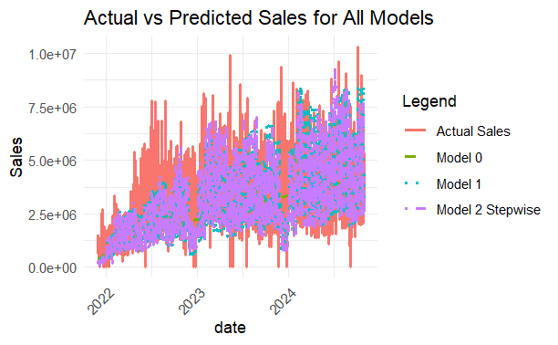

```r
# Add predictions from the final stepwise model
df_merged_d <- add_predictions(ols2_stepwise_d, df_merged_d, "predicted_sales2")

# Plot Actual vs Predicted Values
ggplot(df_merged_d, aes(x = date)) +
  geom_line(aes(y = exp(sales_cop), color = "Actual Sales"), size = 1) +
  geom_line(aes(y = exp(predicted_sales0), color = "Model 0"), linetype = "dashed", size = 1) +
  geom_line(aes(y = exp(predicted_sales1), color = "Model 1"), linetype = "dotted", size = 1) +
  geom_line(aes(y = exp(predicted_sales2), color = "Model 2 Stepwise"), linetype = "dotdash", size = 1) +
  labs(title = "Actual vs Predicted Sales for All Models",
       x = "date", y = "Sales", color = "Legend") +
  theme_minimal() +
  theme(axis.text.x = element_text(angle = 45, hjust = 1))
```

```r
# Models to compare
models_d <- list(
  "Model trend" = ols0d,
  "Model trend + season" = ols1d,
  "Model all covariates step" = ols2_stepwise_d
)

# Get R^2 and AIC for each model
model_stats_d <- get_model_stats(models_d)

# View the results
print(model_stats_d)
```

| Model | R2 | AIC |
| --- | --- | --- |
| Model trend | 0.08382823 | 4133.380 |
| Model trend + season | 0.15572908 | 4082.381 |
| Model all covariates step | 0.16020994 | 4078.846 |

```r
# Calculate RMSE for each model on daily data
rmse_stats_d <- data.frame(
  Model = character(),
  RMSE = numeric(),
  stringsAsFactors = FALSE
)

for (i in seq_along(models_d)) {
  model_name <- names(models_d)[i]
  predicted_column <- paste0("predicted_sales", i - 1) # Adjust index as per your data
  rmse <- calculate_rmse(df_merged_d$sales_cop, df_merged_d[[predicted_column]])
  rmse_stats_d <- rbind(rmse_stats_d, data.frame(Model = model_name, RMSE = rmse))
}

# View RMSE statistics for daily data
print(rmse_stats_d)
```

| Model | RMSE |
| --- | --- |
| Model trend | 1.760115 |
| Model trend + season | 1.689637 |
| Model all covariates step | 1.685147 |

```r
NA
```

## Non Linear Models

Here we explore non linear models, starting from the simplest to more elaborate models in the end combining some of the used models.

### Wrangle data for models

The time series are altered so the visualizations are more understandable, basically we change the date index in the timeseries objects

```r
# re-declare time-series beacause we droped some rows:
# Ensure the 'date' columns are in Date format
df_merged_d$date <- as.Date(df_merged_d$date)
df_merged_w$date <- as.Date(df_merged_w$week)
df_merged_m$date <- as.Date(df_merged_m$month)

# Extract the start date and year for each dataframe
start_d <- min(df_merged_d$date)
start_w <- min(df_merged_w$date)
start_m <- min(df_merged_m$date)

# Extract components for daily, weekly, and monthly start times
start_d_year <- as.numeric(format(start_d, "%Y"))
start_d_day <- as.numeric(format(start_d, "%j")) # Day of the year

start_w_year <- as.numeric(format(start_w, "%Y"))
start_w_week <- as.numeric(format(start_w, "%U")) + 1 # Week number, adding 1 since R starts at week 0

start_m_year <- as.numeric(format(start_m, "%Y"))
start_m_month <- as.numeric(format(start_m, "%m"))

# Declare time series with appropriate frequencies
sales_d_ts <- ts(exp(df_merged_d$sales_cop), start = c(start_d_year, start_d_day), frequency = 365)
sales_w_ts <- ts(exp(df_merged_w$sales_w), start = c(start_w_year, start_w_week), frequency = 52)
sales_m_ts <- ts(exp(df_merged_m$sales_m), start = c(start_m_year, start_m_month), frequency = 12)

food_d_ts <- ts(exp(df_merged_d$food), start = c(start_d_year, start_d_day), frequency = 365)
food_w_ts <- ts(exp(df_merged_w$food_w), start = c(start_w_year, start_w_week), frequency = 52)
food_m_ts <- ts(exp(df_merged_m$food_m), start = c(start_m_year, start_m_month), frequency = 12)

bar_d_ts <- ts(exp(df_merged_d$bar), start = c(start_d_year, start_d_day), frequency = 365)
bar_w_ts <- ts(exp(df_merged_w$bar_w), start = c(start_w_year, start_w_week), frequency = 52)
bar_m_ts <- ts(exp(df_merged_m$bar_m), start = c(start_m_year, start_m_month), frequency = 12)
```

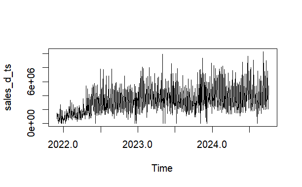

```r
# Verify the created time series
par(mfrow=c(1,1))
plot(sales_d_ts)
```

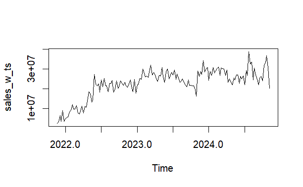

```r
plot(sales_w_ts)
```

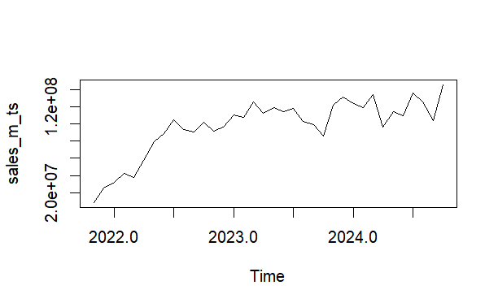

```r
plot(sales_m_ts)
```

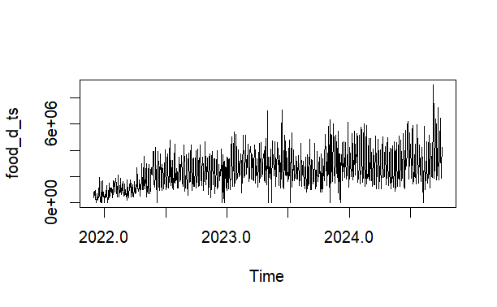

```r
plot(food_d_ts)
```

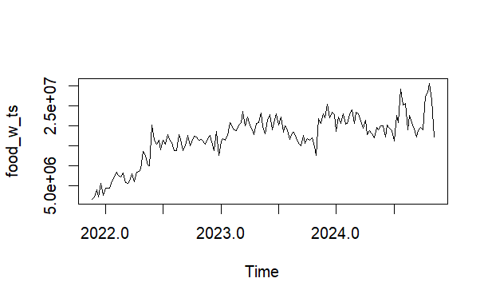

```r
plot(food_w_ts)
```

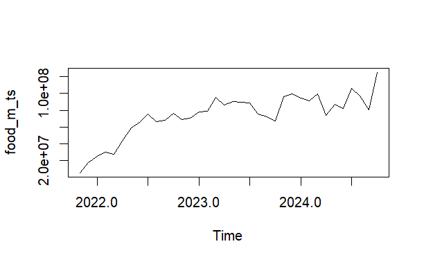

```r
plot(food_m_ts)
```

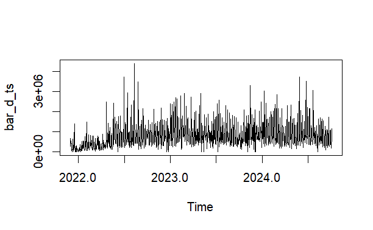

```r
plot(bar_d_ts)
```

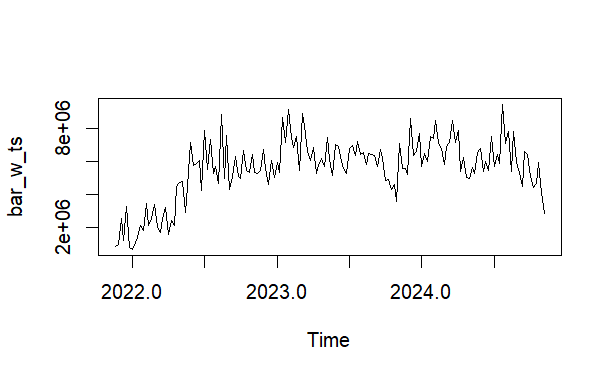

```r
plot(bar_w_ts)
```

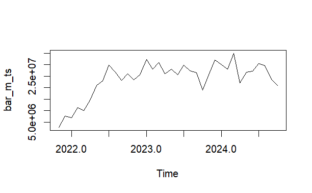

```r
plot(bar_m_ts)
```

Here we fill the sales = 0 values with the mean of the two adjacent dates. This in order to have smoother models. The dates with sales = 0 are dates that are national holiday like christmas or new years, or inventory day in which the kitchen cannot operate so the sales are 0.

```r
# Function to replace 1s with the mean of previous and next observations
fill_ones <- function(ts_data) {
  # Convert time series to numeric vector
  ts_vec <- as.numeric(ts_data)

  # Loop through and replace 1s
  for (i in seq_along(ts_vec)) {
    if (ts_vec[i] == 1) {
      # Check boundaries to avoid indexing issues
      prev_val <- ifelse(i > 1, ts_vec[i - 1], NA)
      next_val <- ifelse(i < length(ts_vec), ts_vec[i + 1], NA)

      # Replace with mean of previous and next, ignoring NA
      ts_vec[i] <- mean(c(prev_val, next_val), na.rm = TRUE)
    }
  }

  # Return as time series with original attributes
  ts(ts_vec, start = start(ts_data), frequency = frequency(ts_data))
}

# Apply the function
sales_d_ts <- fill_ones(sales_d_ts)
sales_w_ts <- fill_ones(sales_w_ts)
sales_m_ts <- fill_ones(sales_m_ts)


food_d_ts <- fill_ones(food_d_ts)
food_w_ts <- fill_ones(food_w_ts)
food_m_ts <- fill_ones(food_m_ts)

bar_d_ts <- fill_ones(bar_d_ts)
bar_w_ts <- fill_ones(bar_w_ts)
bar_m_ts <- fill_ones(bar_m_ts)
```

### Bass Model

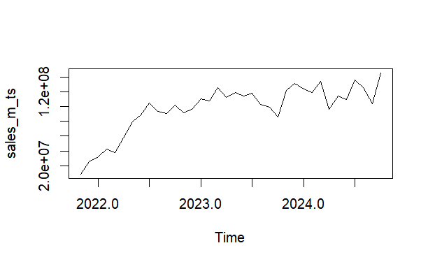

```r
# Some simple plots
plot(sales_m_ts)
```

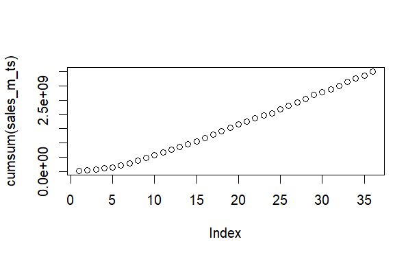

```r
plot(cumsum(sales_m_ts)) #Returns a vector whose elements are the cumulative sums
```

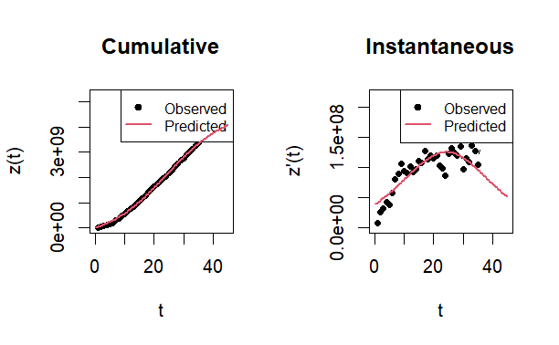

```r
# Bass model
bm_m<-BM(sales_m_ts,display = T) # show graphical view of results / display = True
```

```r
summary(bm_m)
```

```
Call: ( Standard Bass Model )

  BM(series = sales_m_ts, display = T)

Residuals:
      Min.   1st Qu.    Median      Mean   3rd Qu.
-94382506 -37311459 -12636337 -10394220  24066002
     Max.
 75506534

Coefficients:
```

|  | Estimate | Std.Error | Lower | Upper | p-value |  |
| --- | --- | --- | --- | --- | --- | --- |
| m | 4.664349e+09 | 2.000317e+08 | 4.272294e+09 | 5.056404e+09 | 4.48e-22 | *** |
| p | 8.332383e-03 | 2.359472e-04 | 7.869934e-03 | 8.794831e-03 | 8.52e-28 | *** |
| q | 8.966748e-02 | 5.371447e-03 | 7.913963e-02 | 1.001953e-01 | 1.18e-17 | *** |

```
---
 Signif. codes:  0 '***' 0.001 '**' 0.01 '*' 0.05 '.' 0.1 ' ' 1

 Residual standard error  47282474  on  33  degrees of freedom
 Multiple R-squared:   0.999374  Residual sum of squares:  7.377587e+16
```

```r
bm_m$coefficients['m'] - sum(sales_m_ts)
```

```
         m
1148560231
```

Also the restaurants rely in word of mouth to reach full stage m = 4.664.000.000 COP, i.e 1 mm EUR approx. / The restaurant has sold 3.515.788.885/ According to this only in 1 year it should extinguish sells p, innovation: 0.832% indicates that the adoption rate due to external influence is relatively low, but not uncommon for many markets. - it is actually relativly innovative q: (8.96%) suggests that imitation plays a larger role than innovation in driving adoption in this market

```r
pred_bm_m<- predict(bm_m, newx=c(1:length(sales_m_ts)))
pred_bm_m <- ts(pred_bm_m, start = start(sales_m_ts), frequency = frequency(sales_m_ts))
pred.inst_bm_m <- make.instantaneous(pred_bm_m)
pred.inst_bm_m <- ts(pred.inst_bm_m, start = start(sales_m_ts), frequency = frequency(sales_m_ts))

# plot
plot(sales_m_ts, type = "p", col = "black", pch = 16, cex = 0.7,
     xlab = "Month", ylab = "Monthly Sales", main = "Actual vs Fitted Sales")

# Add the fitted values as a line
lines(pred.inst_bm_m, col = "red", lwd = 2)
```

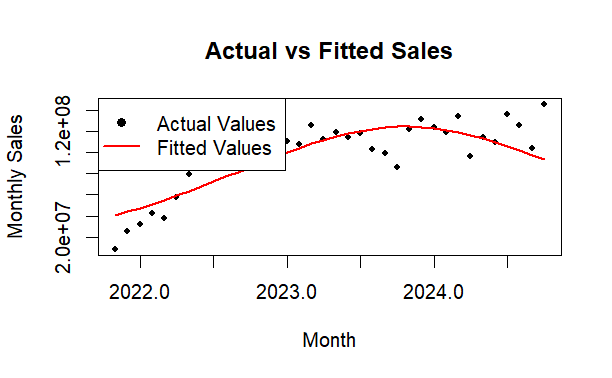

```r
# Add a legend
legend("topleft", legend = c("Actual Values", "Fitted Values"),
       col = c("black", "red"), pch = c(16, NA), lty = c(NA, 1), lwd = c(NA, 2))
```

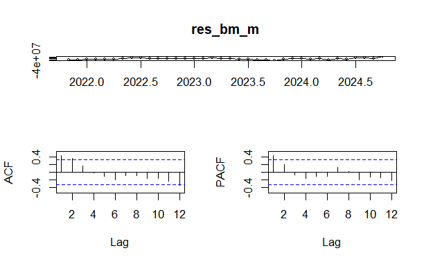

```r
# check residuals
res_bm_m <- sales_m_ts - pred.inst_bm_m
tsdisplay(res_bm_m)
```

Residuals have some structure and 2 lag has correlation.

```r
# Calculate RMSE for Bass Model predictions
rmse_bm_m <- calculate_rmse(observed = sales_m_ts, predicted = pred.inst_bm_m)

# Print the RMSE
cat("RMSE for Bass Model Predictions:", rmse_bm_m, "\n")
```

```
RMSE for Bass Model Predictions: 18498870
```

Estimating the model with 50% of the data

```r
### Estimating the model with 50% of the data
bm_monthly_sales50 <- BM(sales_m_ts[1:17],display = T)
summary(bm_monthly_sales50)
```

```r
pred_bm_monthly_sales50 <- predict(bm_monthly_sales50, newx=c(1:50))
pred.inst_m50 <- make.instantaneous(pred_bm_monthly_sales25)

plot(sales_m_ts,
     type= "b",
     xlab="Months",
     ylab="Monthly Sales",
     pch=16,
     lty=3,
     xaxt="n",
     cex=0.6)

axis(1, at=c(1,10,20,30,35), labels=df_merged_m$month[c(1,10,20,30,35)])
lines(pred.inst_m50, lwd=2, col=2)
```

Estimating the model with 25% of the data

```r
### Estimating the model with 25% of the data
bm_monthly_sales25 <- BM(sales_m_ts[1:9],display = T)
summary(bm_monthly_sales25)

pred_bm_monthly_sales25 <- predict(bm_monthly_sales25, newx=c(1:50))
pred.inst_m25 <- make.instantaneous(pred_bm_monthly_sales25)
```

```r
plot(sales_m_ts,
     type= "b",
     xlab="Months",
     ylab="Monthly Sales",
     pch=16,
     lty=3,
     xaxt="n",
     cex=0.6)

axis(1, at=c(1,10,20,30,35), labels=df_merged_m$month[c(1,10,20,30,35)])
lines(pred.inst_m25, lwd=2, col=2)
```

Comparison between models (instantaneous)

```r
###Comparison between models (instantaneous)
###instantaneous
plot(sales_m_ts,
     type= "b",
     xlab="Months",
     ylab="Monthly Sales",
     pch=16,
     lty=3,
     xaxt="n",
     cex=0.6)

axis(1, at=c(1,10,20,30,35), labels=df_merged_m$month[c(1,10,20,30,35)])
lines(pred.inst_m25, lwd=2, col=2)
lines(pred.inst_m50, lwd=2, col=3)
lines(pred.inst_m, lwd=2, col=4)
```

```r
###Comparison between models (cumulative)
plot(cumsum(sales_m_ts),
     type= "b",
     xlab="Months",
     ylab="Cumulative Sum",
     pch=16,
     lty=3,
     xaxt="n",
     cex=0.6)

axis(1, at=c(1,10,20,30,35), labels=df_merged_m$month[c(1,10,20,30,35)])

lines(pred_bm_monthly_sales25, lwd=2, col=2)
lines(pred_bm_monthly_sales50, lwd=2, col=3)
lines(pred_bm_monthly_sales, lwd=2, col=4)
```

```r
#bm_monthly_sales25
```

#### Limitation of of the Bass Model

- Bass model assumes that every product succeeds and the sales saturate to the steady state level. However, most new products fail in reality.
- The market potential *m* is constant along the whole life cycle.
- Bass model predictions works well only after the scale inflection point. if sales of a category goes up and up like a J-curve, it can over estimate the overall market size.
- It is a model for products with a limited life cycle: needs a hypothesis.
- Another drawback of Bass model is that the diffusion pattern in not affected by marketing mix variables like price or advertising.

The generalized Bass model extends the original Bass model allowing the roles of marketing mix value.

### Generalized Bass Model

Bass model is used to forecast the adoption of a new product and to predict the sales, since it determines the shape of the curve of a model that represent the cumulative adoption of a new product. The Generalized Bass model extends the original Bass model by incorporating marketing mix variables. We can know the effect of pricing, promotions on the new product diffusion curve. It is more flexible than the original Bass model.

```r
m <- 4.451570e+09
p <- 8.472917e-03
q <- 9.415625e-02

GBM_monthly_sales <- GBM(
  sales_m_ts,
  shock = 'exp',
  nshock = 1,
  #prelimestimates = c(m,p,q, 12, 0.1, -0.1)
  prelimestimates = c(m,p,q, 10, 0.1, 2)
  #prelimestimates = c(m,p,q, 11, 15, -0.1)
  )

summary(GBM_monthly_sales)

pred_GBM_monthly_sales<- predict(GBM_monthly_sales, newx=c(1:60))
pred_GBM_monthly_sales.inst<- make.instantaneous(pred_GBM_monthly_sales)
```

### Guseo-Guidolin Model

```r
GGM_monthly_sales <- GGM(sales_m_ts,  prelimestimates = NULL)

summary(GGM_monthly_sales)
```

```r
GGM_monthly_sales
```

K <- 7.683785e+09

pc <- 2.698613e-02

qc <- 2.582412e-01

ps <- 7.731763e-03

qs <- 4.508202e-02

```r
pred_GGM_monthly_sales <- predict(GGM_monthly_sales, newx=c(1:60))
pred.instGGM_monthly_sales <- make.instantaneous(pred_GGM_monthly_sales)

plot(sales_m_ts,
     type= "b",
     xlab="Months",
     ylab="Monthly Sales",
     pch=16,
     lty=3,
     xaxt="n",
     cex=0.6)

axis(1, at=c(1,10,20,30,35), labels=df_merged_m$month[c(1,10,20,30,35)])
lines(pred.instGGM_monthly_sales, lwd=2, col=2)
```

### ARIMA models

ARIMA is a acronym for Auto Regressive Integrated Moving Average, ARIMA (p,d,q) where p refers to the AR part, q refers to the MA part and d is the degree of first difference involved.

```r
library(fpp2)
library(forecast)
?fpp2
```

#### Daily sales

```r
# ARIMA model
plot(sales_d_ts)
```

```r
sales_d_ts_diff <- diff(sales_d_ts)
tsdisplay(sales_d_ts_diff)
```

KPSS test

The process of using a sequence of KPSS tests (page 300) to determine the appropriate number of first differences is carried out by the function ndiffs() .

```r
ndiffs(sales_d_ts)
```

```r
#nsdiffs(sales_d_ts)
```

```r
auto_arima_d <- auto.arima(sales_d_ts)
summary(auto_arima_d)

autoplot(forecast(auto_arima_d))
checkresiduals(auto_arima_d)
```

#### Weekly sales

```r
plot(sales_w_ts)
```

```r
sales_w_ts_diff <- diff(sales_w_ts)
plot(sales_w_ts_diff)
acf(sales_w_ts_diff)
pacf(sales_w_ts_diff)
```

```r
ndiffs(sales_w_ts)
```

```r
auto_arima_w <- auto.arima(sales_w_ts)
auto_arima_w

autoplot(forecast(auto_arima_w))
checkresiduals(auto_arima_w)
```

#### Monthly sales

```r
plot(sales_m_ts)
```

```r
ndiffs(sales_m_ts)
```

```r
sales_m_ts_diff <- diff(sales_m_ts)
plot(sales_m_ts_diff)
acf(sales_m_ts_diff)
pacf(sales_m_ts_diff)
```

```r
auto_arima_m <- auto.arima(sales_m_ts)
auto_arima_m

autoplot(forecast(auto_arima_m))
checkresiduals(auto_arima_m)
```

An ARIMA(0,1,0) model is suitable when:

- The time series is non-stationary and becomes stationary after first differencing.
- There are no significant autocorrelations in the differenced series, indicating that past values do not help in predicting future values beyond the differencing.
- There are no significant moving average components (i.e., past forecast errors do not help in predicting future values).

#### Seasonality

```r
plot(sales_m_ts)
```

```r
#nsdiffs(sales_m_ts)
```

Here we are considering seasonality in the monthly sales time series

The data are clearly non-stationary, with some assumed seasonality, so we will first take a seasonal difference.

```r
sales_m_ts %>% diff(lag=12) %>% ggtsdisplay()
```

```r
sales_m_ts %>% diff(lag=12) %>% diff() %>% ggtsdisplay()
```

```r
arima_m_season <- Arima(sales_m_ts, order=c(0,1,1), seasonal=c(0,1,1))
arima_m_season
checkresiduals(arima_m_season)
```

Forecasting

```r
arima_m_season %>% forecast(h=12) %>% autoplot()
```

Auto ARIMA

```r
auto_arima_m_season <- auto.arima(sales_m_ts, D=1, seasonal = TRUE)
auto_arima_m_season
checkresiduals(auto_arima_m_season)
```

```r
auto_arima_m_season %>% forecast(h=12) %>% autoplot()
```

### Exponential Smoothing methods

#### Simple Exponential Smoothing

##### Daily sales

Daily Sales

For daily data, exponential smoothing can be used to forecast short-term trends and seasonal patterns. When applying exponential smoothing to daily data, you need to consider:

- **Seasonality**: Daily data often exhibit seasonal patterns, such as weekly cycles (e.g., higher sales on weekends).
- **Holidays and special events**: These can cause irregular patterns in daily data that may need to be accounted for.

```r
# Simple Exponential Smoothing for daily sales

plot(sales_d_ts)
```

```r
fit_d1 <- ses(sales_d_ts, alpha = 0.2, initial = 'simple', h=5)
fit_d2 <- ses(sales_d_ts, alpha = 0.6, initial = 'simple', h=5)
fit_d3 <- ses(sales_d_ts, h=5)

plot(sales_d_ts, ylab='Daily Sales', xlab='Days')
lines(fitted(fit_d1), col='blue', type='o')
lines(fitted(fit_d2), col='red', type='o')
lines(fitted(fit_d3), col='green', type='o')
```

```r
forecast_d1 <- ses(sales_d_ts, h=5)
round(accuracy(forecast_d1),2)

summary(forecast_d1)

autoplot(forecast_d1) + autolayer(fitted(forecast_d1),series='Fitted') + ylab("Daily Sales")+xlab("Days")
```

##### Weekly Sales

Weekly Sales

For weekly data, exponential smoothing can capture longer-term trends and seasonal patterns that repeat on a weekly basis. Weekly data can also have seasonal components related to months, quarters, or years.

```r
# Simple Exponential Smoothing for weekly sales
plot(sales_w_ts)
```

```r
fit_w1 <- ses(sales_w_ts, alpha = 0.2, initial = 'simple', h=5)
fit_w2 <- ses(sales_w_ts, alpha = 0.6, initial = 'simple', h=5)
fit_w3 <- ses(sales_w_ts, h=5)

plot(sales_w_ts, ylab='Weekly Sales', xlab='Weeks')
lines(fitted(fit_w1), col='blue', type='o')
lines(fitted(fit_w2), col='red', type='o')
lines(fitted(fit_w3), col='green', type='o')
```

```r
forecast_w1 <- ses(sales_w_ts, h=5)
round(accuracy(forecast_w1),2)

summary(forecast_w1)

autoplot(forecast_w1) + autolayer(fitted(forecast_w1),series='Fitted') + ylab("Weekly Sales")+xlab("Weeks")
```

##### Monthly Sales

Monthly Sales

```r
# Simple Exponential Smoothing for monthly sales

plot(sales_m_ts)
```

```r
fit_m1 <- ses(sales_m_ts, alpha = 0.2, initial = 'simple', h=5)
fit_m2 <- ses(sales_m_ts, alpha = 0.6, initial = 'simple', h=5)
fit_m3 <- ses(sales_m_ts, h=5)

plot(sales_m_ts, ylab='Monthly Sales', xlab='Weeks')
lines(fitted(fit_m1), col='blue', type='o')
lines(fitted(fit_m2), col='red', type='o')
lines(fitted(fit_m3), col='green', type='o')
```

```r
forecast_m1 <- ses(sales_m_ts, h=5)

# Accuracy of one-step-ahead training errors
round(accuracy(forecast_m1),2)

summary(forecast_m1)

autoplot(forecast_m1) + autolayer(fitted(forecast_m1),series='Fitted') + ylab("Monthly Sales")+xlab("Months")
```

#### Trend Method

Holt Method

```r
plot(sales_m_ts)
```

```r
forecast_holt <- holt(sales_m_ts, h=5)
forecast2_holt <- holt(sales_m_ts, damped = T, phi = 0.9, h=5)

summary(forecast_holt)

autoplot(sales_m_ts) +
  autolayer(forecast_holt, series="Holt's method", PI=F) +
  autolayer(forecast2_holt, series="Damped Holt's method", PI=F) +
  ylab("Monthly Sales")+xlab("Months")
```

#### Trend and seasonality method

```r
sales_m_ts <- ts(sales_m_ts, frequency = 12)
forecast_hw <- hw(sales_m_ts, seasonal = 'additive')
forecast2_hw <- hw(sales_m_ts, seasonal = 'multiplicative')

autoplot(sales_m_ts) +
  autolayer(forecast_hw, series="Holt-Winters' additive", PI=F) +
  autolayer(forecast2_hw, series="Holt-Winters' multi", PI=F)
```

### ARMAX models

#### Rain

```r
df_merged_m
is.ts(df_merged_m)
```

```r
ts_merged_m <- ts(df_merged_m)
is.ts(ts_merged_m)
```

```r
ts_merged_m[,5]
```

```r
# Estimate ARMAX model
armax1_m_rain <- Arima(ts_merged_m[,2], xreg=ts_merged_m[,5], order=c(1,0,1))
res_armax1_rain <- residuals(armax1_m_rain)
Acf(res_armax1_rain)

summary(armax1_m_rain)
plot(ts_merged_m[,2])
lines(fitted(armax1_m_rain), col=2)
```

```r
# Estimate ARMAX model
armax2_m_rain <- Arima(ts_merged_m[,2], xreg=ts_merged_m[,5], order=c(1,0,2))
res_armax2_rain <- residuals(armax2_m_rain)
Acf(res_armax2_rain)

summary(armax2_m_rain)
plot(ts_merged_m[,2])
lines(fitted(armax2_m_rain), col=2)
```

```r
# Estimate ARMAX model
armax3_m_rain <- Arima(ts_merged_m[,2], xreg=ts_merged_m[,5], order=c(1,1,2))
res_armax3_rain <- residuals(armax3_m_rain)
Acf(res_armax3_rain)

summary(armax3_m_rain)
plot(ts_merged_m[,2])
lines(fitted(armax3_m_rain), col=2)
```

```r
########procedure also available with auto.arima
auto.arima_rain <- auto.arima(ts_merged_m[,2], xreg=ts_merged_m[,5])
res_auto.arima_rain <- residuals(auto.arima_rain)
Acf(res_auto.arima_rain)

summary(auto.arima_rain)
plot(ts_merged_m[,2])
lines(fitted(auto.arima_rain), col=2)
```

#### Temperature

```r
# Estimate ARMAX model
armax1_m_temp <- Arima(ts_merged_m[,2], xreg=ts_merged_m[,11], order=c(1,0,1))
res_armax1_temp <- residuals(armax1_m_temp)
Acf(res_armax1_temp)

summary(armax1_m_temp)
plot(ts_merged_m[,2])
lines(fitted(armax1_m_temp), col=2)
```

```r
auto.arima_temp <- auto.arima(ts_merged_m[,2], xreg=ts_merged_m[,11])
res_auto.arima_temp <- residuals(auto.arima_temp)
Acf(res_auto.arima_temp)

summary(auto.arima_temp)
plot(ts_merged_m[,2])
lines(fitted(auto.arima_temp), col=2)
```

#### Inflation

```r
auto.arima_infl <- auto.arima(ts_merged_m[,2], xreg=ts_merged_m[,9])
res_auto.arima_infl <- residuals(auto.arima_infl)
Acf(res_auto.arima_infl)

summary(auto.arima_infl)
plot(ts_merged_m[,2])
lines(fitted(auto.arima_infl), col=2)
```

#### Unemployment

```r
auto.arima_unemp <- auto.arima(ts_merged_m[,2], xreg=ts_merged_m[,10])
res_auto.arima_unemp <- residuals(auto.arima_unemp)
Acf(res_auto.arima_unemp)

summary(auto.arima_unemp)
plot(ts_merged_m[,2])
lines(fitted(auto.arima_unemp), col=2)
```

### SARMAX

Function Arima() of the forecast library works to implement the SARMAX refinement.

Page 66, professor’s book:

The practical application of the ARMAX (or SARMAX) procedure may be summarized in the following steps:

1. Select a nonlinear model f(beta, t) for y(t), e.g. Bass model, Generalized Bass model, and GGM.
2. Perform an analysis of residuals: graphical inspection of residuals, analysis of ACF. If needed, perform some tests, e.g. Durbin-Watson.
3. If there is autocorrelation in the residuals, apply an ARMAX or SARMAX model directly to y(t), by including f(beta_hat, t) as a plug-in covariate.
4. Check the estimation results, by paying special attention to the estimation of parameter lambda.
5. Make a selection of the model based on the AIC.
6. Update the predictions after the refinement.

### Generalized Additive Models

```r
#??????
```

### Prophet

This model was introduced by Facebook ([S. J. Taylor & Letham, 2018](https://otexts.com/fpp3/prophet.html#ref-prophet)), originally for forecasting daily data with weekly and yearly seasonality, plus holiday effects. It was later extended to cover more types of seasonal data. It works best with time series that have strong seasonality and several seasons of historical data.

Prophet can be considered a nonlinear regression model (Chapter [7](https://otexts.com/fpp3/regression.html#regression)), of the form yt=g(t)+s(t)+h(t)+εt, where g(t) describes a piecewise-linear trend (or “growth term”), s(t) describes the various seasonal patterns, h(t) captures the holiday effects, and εt is a white noise error term.

- The knots (or changepoints) for the piecewise-linear trend are automatically selected if not explicitly specified. Optionally, a logistic function can be used to set an upper bound on the trend.
- The seasonal component consists of Fourier terms of the relevant periods. By default, order 10 is used for annual seasonality and order 3 is used for weekly seasonality.
- Holiday effects are added as simple dummy variables.
- The model is estimated using a Bayesian approach to allow for automatic selection of the changepoints and other model characteristics.

```r
library(prophet)
```

The input to Prophet is always a dataframe with two columns: ds and y . **The ds (datestamp) column should be of a format, ideally YYYY-MM-DD for a date or YYYY-MM-DD HH:MM:SS for a timestamp**. The y column must be numeric, and represents the measurement we wish to forecast.

#### Monthly sales

```r
# sales montly
ggplot(df_sales_m, aes(x=month, y=sales_m)) +
  geom_line() + ggtitle("Monthly Sales of Restaurant")

head(df_sales_m)
```

```r
#Prophet model
# model with no seasonality
df_prophet_m <- df_sales_m[1:2]
colnames(df_prophet_m) = c("ds", "y")
df_prophet_m

prophet_sales_m <- prophet(df_prophet_m)
```

```r
future_sales_m <- make_future_dataframe(prophet_sales_m,
                                        periods = 14,
                                        freq = 'month',
                                        include_history = T
                                        )
tail(future_sales_m)
```

```r
forecast_sales_m <- predict(prophet_sales_m, future_sales_m)
tail(forecast_sales_m[c('ds', 'yhat', 'yhat_lower', 'yhat_upper')])

plot(prophet_sales_m, forecast_sales_m)
```

```r
prophet_plot_components(prophet_sales_m, forecast_sales_m)
```

```r
dyplot.prophet(prophet_sales_m, forecast_sales_m)
```

#### Weekly sales

```r
ggplot(df_sales_w, aes(x=week, y=sales_w)) +
  geom_line() + ggtitle("Weekly Sales of Restaurant")
```

```r
head(df_sales_w)
```

```r
#Prophet model
# model with no seasonality
df_prophet_w <- df_sales_w[1:2]
colnames(df_prophet_w) = c("ds", "y")
df_prophet_w

#prophet_sales_w <- prophet(df_prophet, daily.seasonality = TRUE)
prophet_sales_w <- prophet(df_prophet_w)
```

Predictions are made on a dataframe with a column `ds` containing the dates for which predictions are to be made. The `make_future_dataframe` function takes the model object and a number of periods to forecast and produces a suitable dataframe. By default it will also include the historical dates so we can evaluate in-sample fit.

```r
future_sales_w <- make_future_dataframe(prophet_sales_w,
                                        periods = 52,
                                        freq = 'week',
                                        include_history = T)
tail(future_sales_w)
```

As with most modeling procedures in R, we use the generic `predict` function to get our forecast. The `forecast` object is a dataframe with a column `yhat` containing the forecast. It has additional columns for uncertainty intervals and seasonal components.

```r
# R
forecast_sales_w <- predict(prophet_sales_w, future_sales_w)
tail(forecast_sales_w[c('ds', 'yhat', 'yhat_lower', 'yhat_upper')])
```

```r
plot(prophet_sales_w, forecast_sales_w)
```

You can use the `prophet_plot_components` function to see the forecast broken down into trend, weekly seasonality, and yearly seasonality.

```r
prophet_plot_components(prophet_sales_w, forecast_sales_w)
```

```r
dyplot.prophet(prophet_sales_w, forecast_sales_w)
```

#### Daily Sales

```r
head(sales)

ggplot(
  sales,
  aes(x=date, y=sales_cop)
  ) + geom_line() + ggtitle("Daily Sales of Restaurant")
```

```r
#Prophet model
# model with no seasonality
df_prophet <- sales[1:2]
colnames(df_prophet) = c("ds", "y")
df_prophet

#prophet_sales_d <- prophet(df_prophet, weekly.seasonality = TRUE)
prophet_sales_d <- prophet(df_prophet)
```

```r
future_sales_d <- make_future_dataframe(prophet_sales_d,
                                        periods = 60,
                                        freq = 'day',
                                        include_history = T)
tail(future_sales_w)
```

```r
forecast_sales_d <- predict(prophet_sales_d, future_sales_d)
tail(forecast_sales_d[c('ds', 'yhat', 'yhat_lower', 'yhat_upper')])
```

```r
plot(prophet_sales_d, forecast_sales_d)
```

```r
prophet_plot_components(prophet_sales_d, forecast_sales_d)
```

```r
dyplot.prophet(prophet_sales_d, forecast_sales_d)
```

### Gradient Boosting

```r
library(gbm)
```

```r
?gbm
```